# Day 7: Data visualization with ggplot

Kumar Ramanathan (with revisions by Richard Paquin Morel

2020-08-17

# Introduction to ggplot

## What is ggplot?

The `ggplot2` package is part of `tidyverse`, a suite of packages maintained by the RStudio company. In ggplot, graphics are built by supplying *data* and *mapping* of data values to aesthetics, and then adding *layers* that build geometric objects, scales, labels, and more.

Before using ggplot, make sure to load the package. You can either load `tidyverse` or `ggplot2` directly.

```r
library(tidyverse)
library(ggplot2)
```

## Why ggplot?

- It is highly customizable and extensible.
- It is designed to work well with `dplyr` and other `tidyverse` packages.
- It has been in use for over 10 years, meaning that help is widely available.
- Its wide usage has also given rise to a wide variety of avilable [extensions](http://www.ggplot2-exts.org/gallery/), including those that handle create interactive graphics (`ggigraph`), animated graphics (`gganimate`), alluvial diagrams (`ggalluvial`), maps (`ggmap`), networks (`ggraph`), and more.
- Consistent “grammar” across different packages/visualizations classes

## Some useful resources

- The [ggplot cheatsheet](https://github.com/rstudio/cheatsheets/blob/master/data-visualization-2.1.pdf) maintained by RStudio is an invaluable resource. I always have it open when using `ggplot2`.
- The [ggplot reference guide](https://ggplot2.tidyverse.org/reference/index.html) maintained by RStudio. In your early days using `ggplot2`, this will be more useful in conjunction with the cheatsheet since it contains more detail on syntax and links to full help files.
- The [Data Visualization chapter](http://r4ds.had.co.nz/data-visualisation.html) in the R for Data Science book by Garrett Grolemund and Hadley Wickham. The rest of the book explores other parts of the `tidyverse`.
- ggedit is an extension package for `ggplot2` that enables users to launch an graphical user interface (GUI) with which to build ggplot graphics layer-by-layer. When completed, the user can copy the code required to generate the plot and return to their script file.
  - There is [some controversy](https://www.youtube.com/watch?v=cpbtcsGE0OA) over whether GUIs diminish creativity and flexibility in data science, but nevertheless, this tool may help early learners get used to the grammar of ggplot.
- And, of course, the help files that come with the package itself.

# Basics: the grammar of graphics

ggplot works by combining several functions using the `+` operator. This creates *layers* in an additive fashion. You can start a new line after each `+` operator for readability if you would like (I do so throughout these notes.) Each function does something specific: provide a dataset, create a geometric object, add labels, add scales, change the coordinate system or layout, change the color palette, etc.

- **Word of warning!!** Don’t confuse the pipe `%>%` from `dplyr` with the `+` from `ggplot2`!

Each graphic generated by ggplot requires at least three basic components:

- **data**: a data frame containing the data that you want to visualize, provided in the `ggplot()` function’s required `data =` argument.
- **geometric objects**: the objects/shapes that you want to plot, indicated through one of the many available `geom` functions, such as `geom_point()` or `geom_hist()`.
- **aesthetic mapping**: the mapping from the data to the geometric objects, provided in an `aes()` function nested within the `mapping =` argument of the `geom` function.
  - You can also provide the `aes()` function to the `mapping =` argument of `ggplot()`. If you do so, *all* `geom` functions will pull from the aesthetic mapping provided in this initial `ggplot()` function.

Together, the basic structure looks like this:

```r
ggplot(data = <DATA FRAME>) +
  <GEOM_FUNCTION>(mapping = aes(<VARIABLES>))
```

To demonstrate with an example, let’s re-create the scatterplot we made in Day 1 using data from Gapminder. Recall that we used the 2007 data subset and plotted the relationship between life expectancy on the y-axis and GDP per capita on the x-axis. Using the structure above, we would proceed as follows:

1. Provide the data in the `data =` argument of the initial `ggplot()` function.
2. Select `geom_point()` as our second function, since the geometric object we want to generate is points.
3. Within the `mapping =` argument of `geom_point()`, we provide our aesthetic mapping. In this case, we need to provide an `x` and `y` variable for the points.

Altogether, it looks like this:

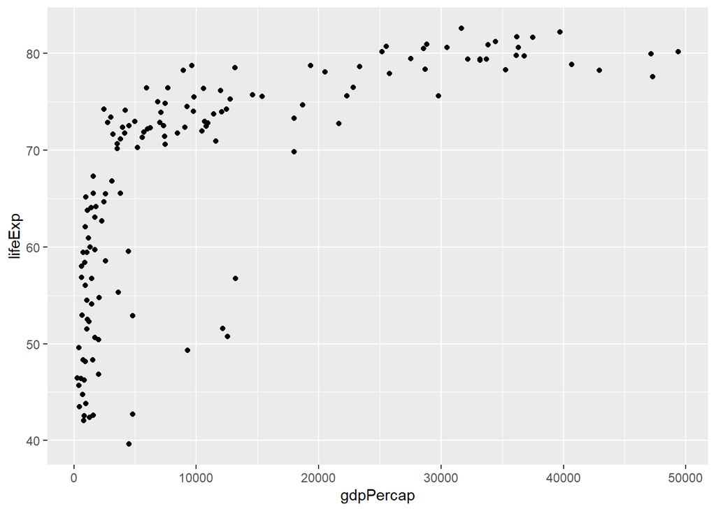

```r
ggplot(data = gapminder07) +
  geom_point(mapping = aes(x = gdpPercap, y = lifeExp))
```

```r
## Or, you can provide the mapping in the call to `ggplot`

# ggplot(data = gapminder07, mapping = aes(x = gdpPercap, y = lifeExp)) +
#  geom_point()
```

Recall how we added a horizontal line to the scatterplot on Day 1. We can replicate that in ggplot by adding another layer using the `geom_hline()` function, which generates another geometric object (specifically, a horizontal line). Notice that `data =` and `mapping =` have been dropped here: as with all functions in R, since these are the first arguments, R assumes that the first inputs provided to the function are for these first arguments.

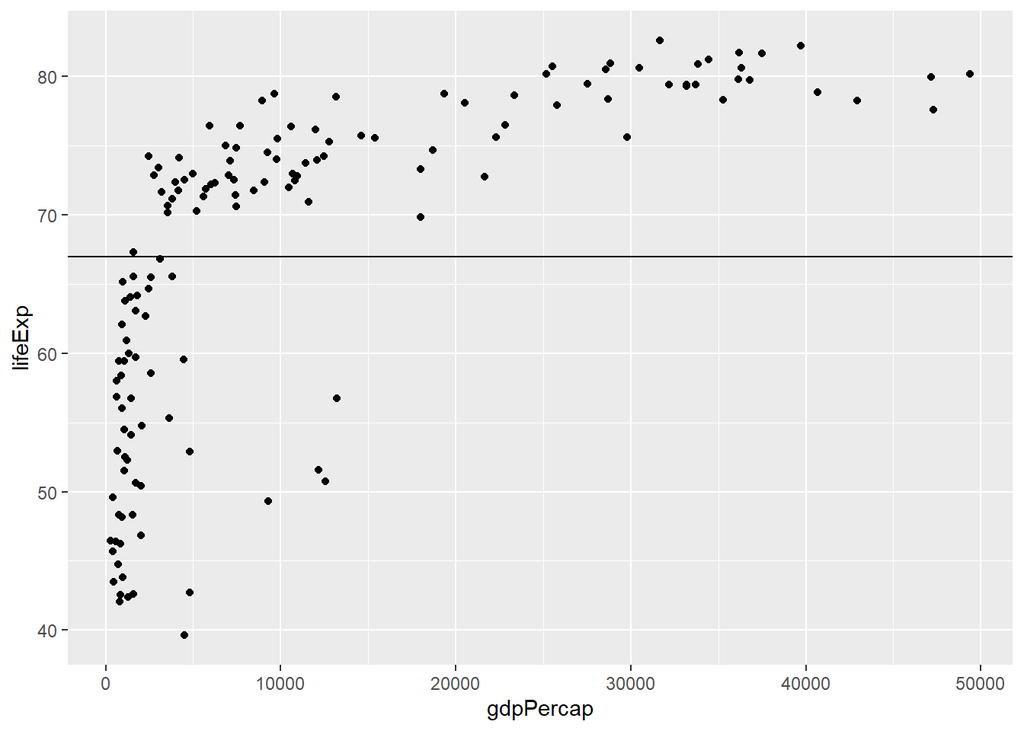

```r
ggplot(gapminder07) +
  geom_point(aes(x = gdpPercap, y = lifeExp)) +
  geom_hline(aes(yintercept = mean(lifeExp)))
```

Remember that you can also the aesthestics in the call to `ggplot`. This allows you to use the same aesthetic mapping across a number of different geoms.

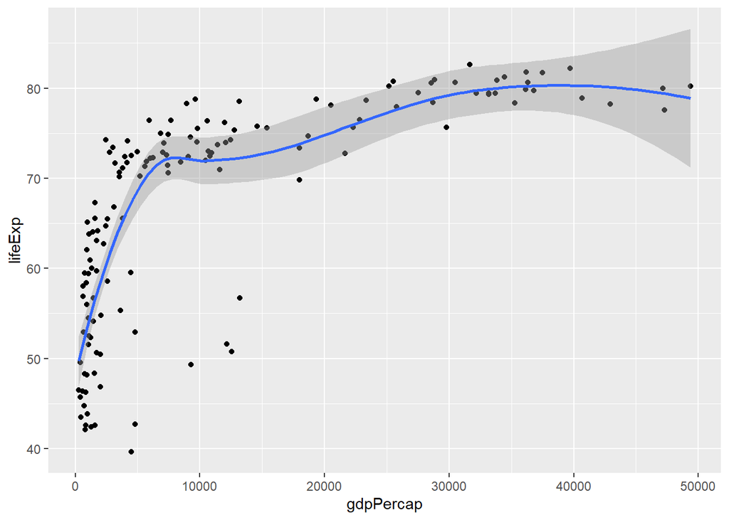

```r
# Doesn't work!
# ggplot(data = gapminder07) +
#  geom_point(mapping = aes(x = gdpPercap, y = lifeExp)) +
#  geom_smooth()

# Works!
ggplot(data = gapminder07, mapping = aes(x = gdpPercap, y = lifeExp)) +
  geom_point() +
  geom_smooth()
```

We can also add titles and axes as a layer using the `labs()` function.

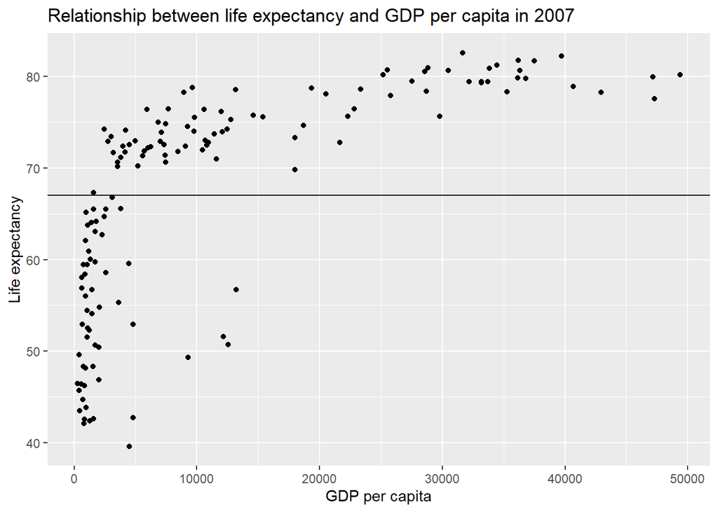

```r
ggplot(data = gapminder07) +
  geom_point(aes(x = gdpPercap, y = lifeExp)) +
  geom_hline(aes(yintercept = mean(lifeExp))) +
  labs(title = "Relationship between life expectancy and GDP per capita in 2007",
       x = "GDP per capita", y = "Life expectancy")
```

As you can see, the grammar of graphics used in ggplot2 breaks down the information that goes into each graphic into several layers, each of which you can customize.

# Preparing your data

Recall the role of pipes (`%>%`) in `dplyr` this morning. Since `dplyr` and `ggplot2` are both part of tidyverse, they are designed to work well together. You can use a series of pipes to prepare your data to be in the appropriate format, subset, etc before plotting.

For example, consider the above plot. Instead of specifying the data in the `ggplot()` function, we can supply the data through a pipe. Instead of using the subsetted `gapminder07` data, we can use the original `gapminder` and use a `filter()` function to select the 2007 observations only.

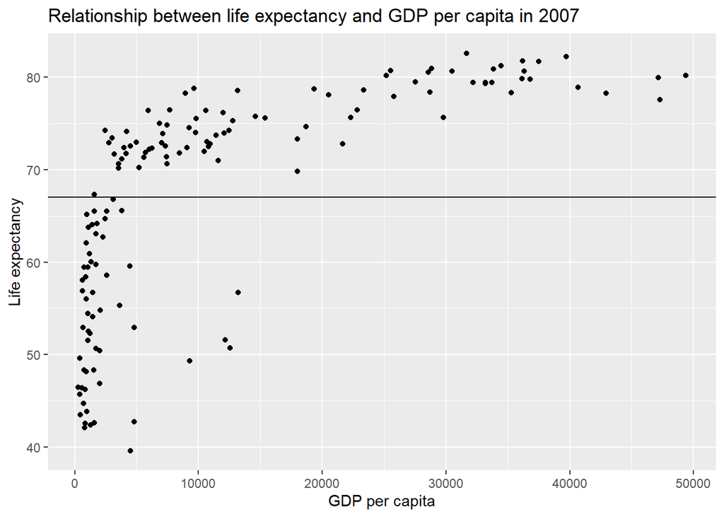

```r
gapminder %>%
  filter(year == 2007) %>%
  ggplot() +
  geom_point(aes(x = gdpPercap, y = lifeExp)) +
  geom_hline(aes(yintercept = mean(lifeExp))) +
  labs(title = "Relationship between life expectancy and GDP per capita in 2007",
       x = "GDP per capita", y = "Life expectancy")
```

For another example of preparing data for plotting, let’s turn to the California energy data, which we will use for the rest of the ggplot session. Recall that in the advanced manipulation session this morning, you used dplyr to create long-format data frames `long_gen` (all generation data) and `long_merged_gen` (all generation + imports data). Say we wanted to visualize the total energy generated in the state over time. Starting with `long_gen`, and using `group_by()` and `summarize()`, we can sum the output for each date-time value (i.e. each hour) and feed this directly into `ggplot()`. Note that this kind of graphing task is one of the uses of having a long-format version of your data.

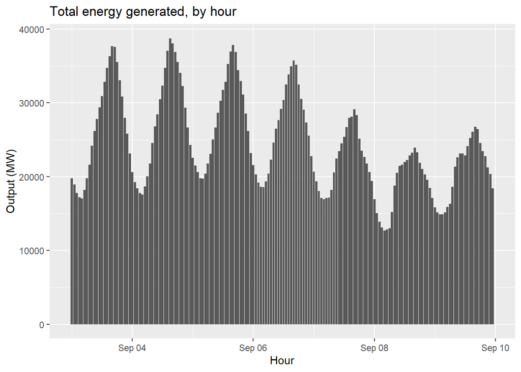

```r
long_gen %>%
  group_by(datetime) %>%
  summarise(output=sum(output)) %>%
  ggplot() +
  geom_col(aes(x=datetime, y=output)) +
  labs(title="Total energy generated, by hour", x="Hour", y="Output (MW)")
```

Perhaps we are concerned that the above plot has too much granularity. Instead, we want to plot the total output per *day* instead of per *hour*. Again, we can achieve this by manipulating our data prior to piping it into `ggplot()`. Note that we use the `date()` function in `lubridate` which takes a date-time value and returns the date portion only.

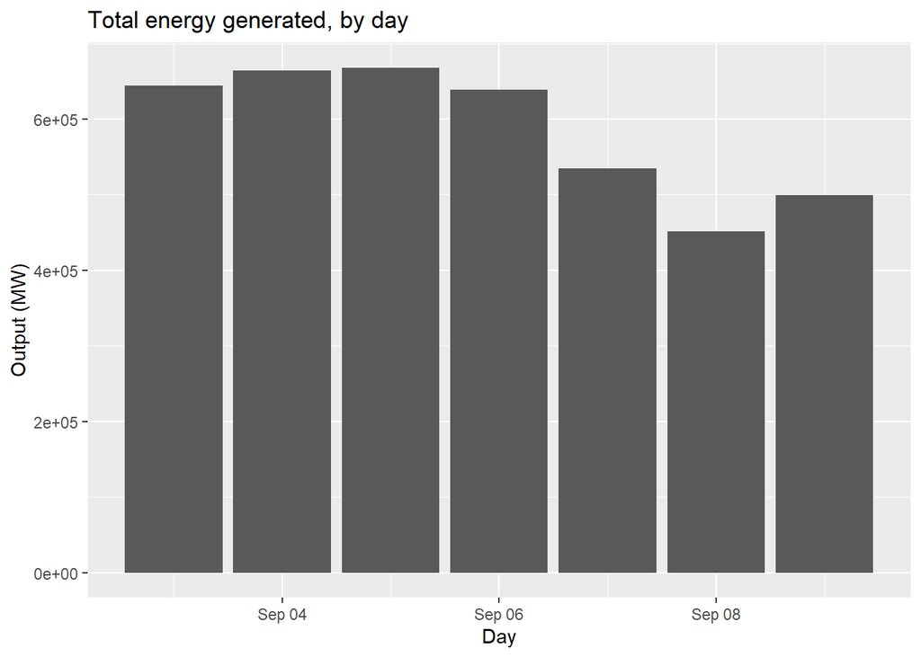

```r
long_gen %>%
  mutate(date=lubridate::date(datetime)) %>%
  group_by(date) %>%
  summarise(output=sum(output)) %>%
  ggplot() +
  geom_col(aes(x=date, y=output)) +
  labs(title="Total energy generated, by day", x="Day", y="Output (MW)")
```

# Geometric objects

We have already seen two kinds of geometries: `geom_point()` which generates points using `x` and `y` values, and `geom_col()` which generates columns for a bar chart. Let’s explore a few more, and learn how to modulate the appearance of the geometric objects created.

## Line plot

Let’s say we’d like to plot the amount of energy imported over time. We can use `geom_line` to generate a line connecting all the data points. To do so, we need to provide `x` and `y` values in the aesthetic mapping function nested within `geom_line()`. Note that we are using the `imports` data frame here, but we could easily use the wide- or long-format merged data frames, as long as we use the appropriate filtering functions.

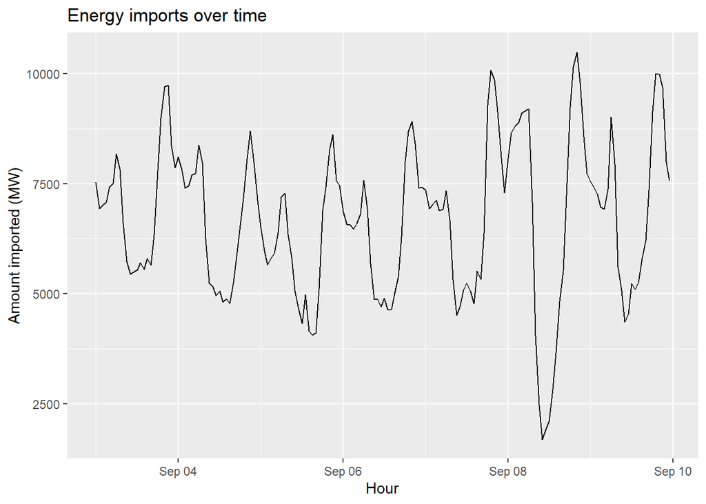

```r
imports %>%
  ggplot() +
  geom_line(aes(x=datetime, y=imports)) +
  labs(title="Energy imports over time", x="Hour", y="Amount imported (MW)")
```

## Changing size and color

Once we have created the geometric object we want, using the appropriate aesthetic mapping, we may want to change the appearance of the object. The features that we can modify vary depending on the `geom` object (the cheatsheet and each function’s reference files are helpful here). For most function, we can modify the size and shape of the object(s) created. Let’s try to increase the size of the line in the plot above and make it red in color. Note that the `col =` and `size =` arguments here are *outside* the `aes()` function since we are not mapping anything from the data frame here.

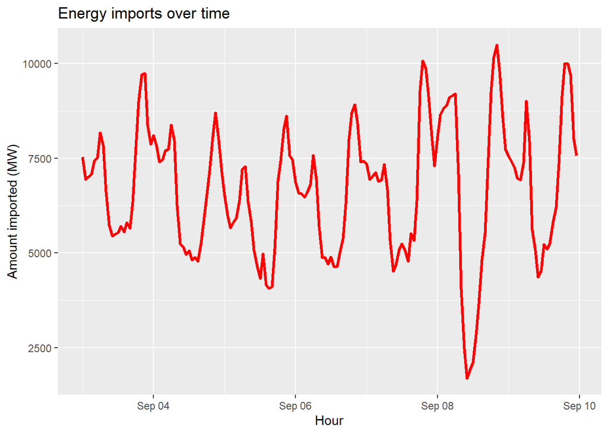

```r
imports %>%
  ggplot() +
  geom_line(aes(x=datetime, y=imports), size=1.2, col="red") +
  labs(title="Energy imports over time", x="Hour", y="Amount imported (MW)")
```

To learn more about the color inputs you can provide in R, see the [R colors cheatsheet](https://www.nceas.ucsb.edu/~frazier/RSpatialGuides/colorPaletteCheatsheet.pdf).

## Area plot

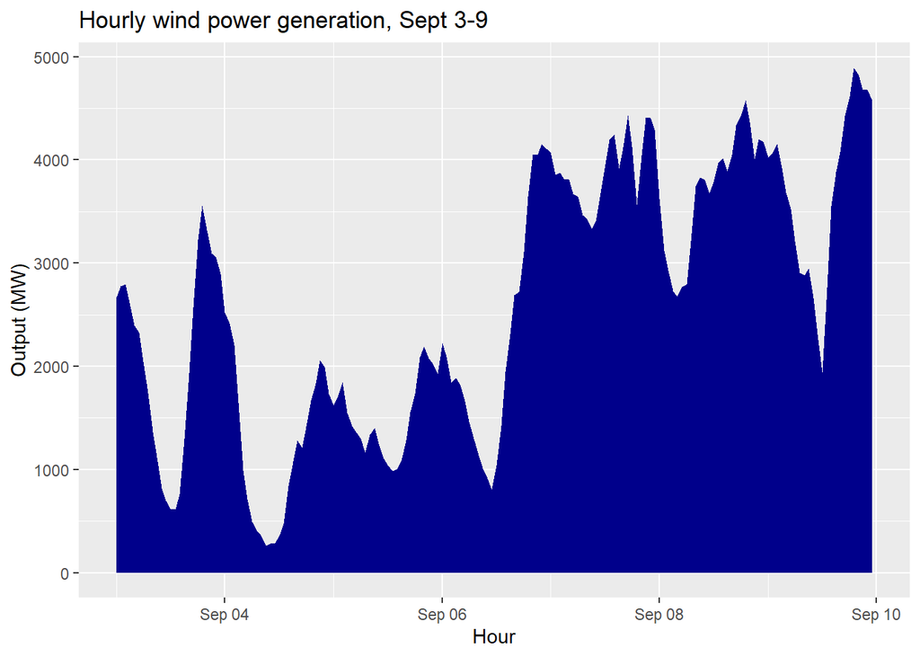

```r
generation %>%
  ggplot() +
  geom_area(aes(x=datetime, y=wind), fill="darkblue") +
  labs(title="Hourly wind power generation, Sept 3-9", x="Hour", y="Output (MW)")
```

## Box plot

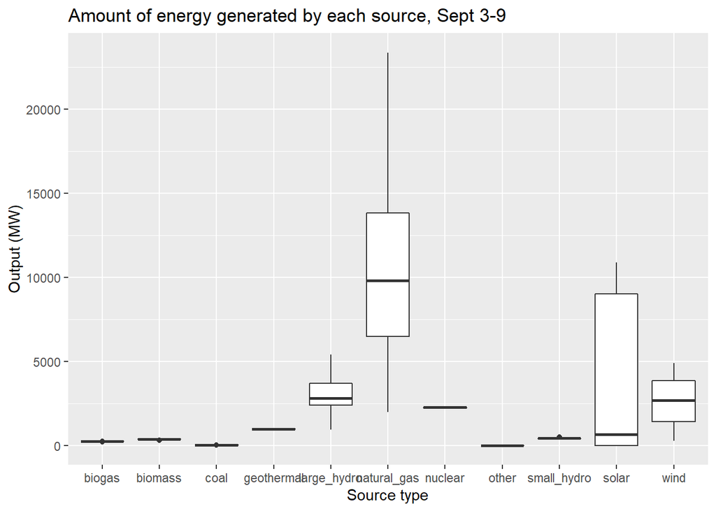

```r
long_gen %>%
  ggplot() +
  geom_boxplot(aes(x=source, y=output)) +
  labs(title="Amount of energy generated by each source, Sept 3-9", x="Source type", y="Output (MW)")
```

## Multiple geometries in one plot

The above examples show cases where one geometric object is plotted per graphic. `ggplot` allows you to add multiple geometric objects as layers. Below is a plot of large hydro power generation over time, first shown using a line with `geom_line()`. On top of that line plot, we can also add a smoothed line with `geom_smooth()`, which plots smoothed conditional means (estimated using a loess regression) in order to aid observation of trends in cases of overplotting.

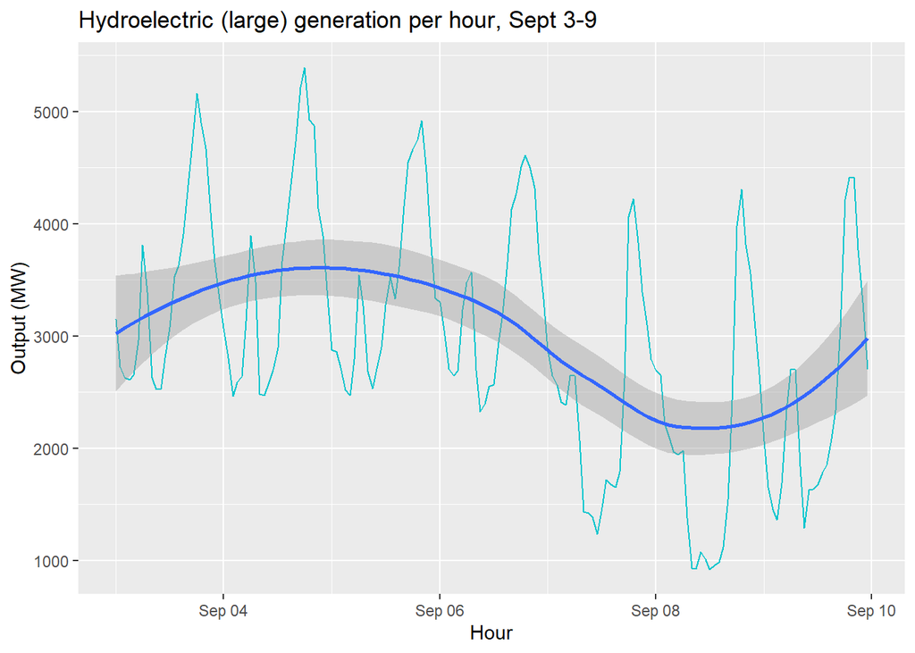

```r
generation %>%
  ggplot(aes(x=datetime, y=large_hydro)) +
  geom_line(, col="turquoise3") +
  geom_smooth(aes(x=datetime, y=large_hydro)) +
  labs(title="Hydroelectric (large) generation per hour, Sept 3-9", x="Hour", y="Output (MW)")
```

An alternative syntax is to do the aesthetic mapping in the `ggplot()` function, after which all `geom` functions will adopt the previously defined aesthetic mapping. The below code generates a plot identical to the above.

```r
merged_energy %>%
  ggplot(aes(x=datetime, y=large_hydro)) +
  geom_line(col="turquoise3") +
  geom_smooth() +
  labs(title="Hydroelectric (large) generation per hour, Sept 3-9", x="Hour", y="Output (MW)")
```

Usually when we plot multiple geometric objects in one graphic, we are trying to plot the same relationship across different groups in the data. We will explore how this works in the below section on visualizing grouped data.

## Other geometric objects

There are many, many more geometric objects that you can create using ggplot. For a full list, see the cheatsheet and reference guide linked above. Several extension packages add even more geometric objects.

# Additional layers

## Labels

We have already seen how we can specify the title and axes labels of a graphic with the `labs()` layer. Note that you can also specify a subtitle and caption for the graphic in the same layer. Let’s see this in action using the line plot of imports data we created earlier.

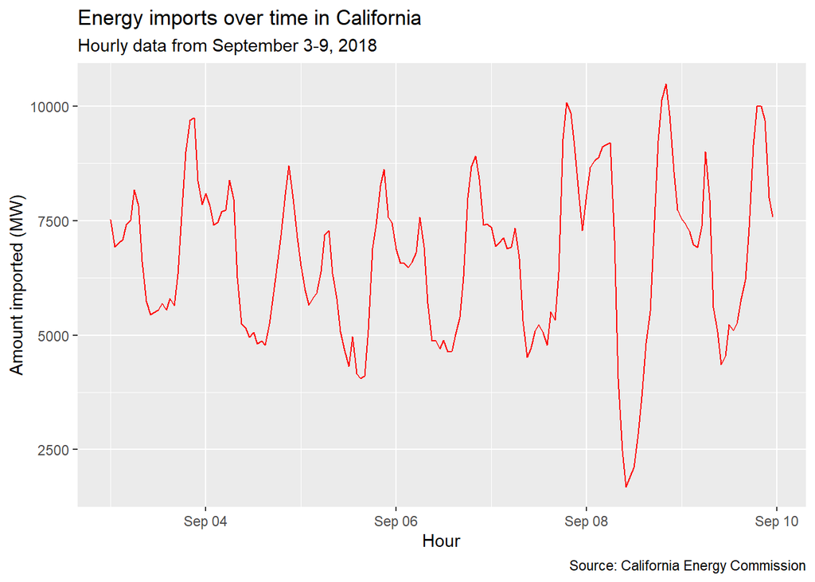

```r
imports %>%
  ggplot() +
  geom_line(aes(x=datetime, y=imports), col="red") +
  labs(title="Energy imports over time in California", subtitle="Hourly data from September 3-9, 2018",
       caption="Source: California Energy Commission",
       x="Hour", y="Amount imported (MW)")
```

For more advanced labeling, you can use the `annotate()` layer, which generates text according to specifications at any point on the coordinate system. See the cheatsheet and reference guide for more details.

## Scales

Scales allow you to manipulate the relationship between data values and aesthetics beyond aesthetic mapping. In other words, they “control the details of how data values are translated to visual properties” (quote from [reference guide](https://ggplot2.tidyverse.org/reference/index.html#section-aesthetics)). You can set the transparency of objects using `scale_alpha` functions, modify color palettes using `scale_color` and `scale_fill` functions, the position of axis markers using `scale_x` and `scale_y` functions, and more. The cheatsheet helpfully organizes scale functions based on the type of task they are suited for, and can see a full list of scale functions in the reference guide.

To see an example at work, let’s use the `scale_x_datetime()` function to manipulate the scaling and display of datetime values of the x-axis. Specifically, we will use `date_labels =` to define which labels to use for the date values and `date_breaks =` to define how far apart the breaks between the x-axis ticks should be.

(Note: `%H:%M` means the datetime should be displayed in 24-hour clock format without any date information; you can see a list of datetime conversion specifications in R by looking up `?strptime`.)

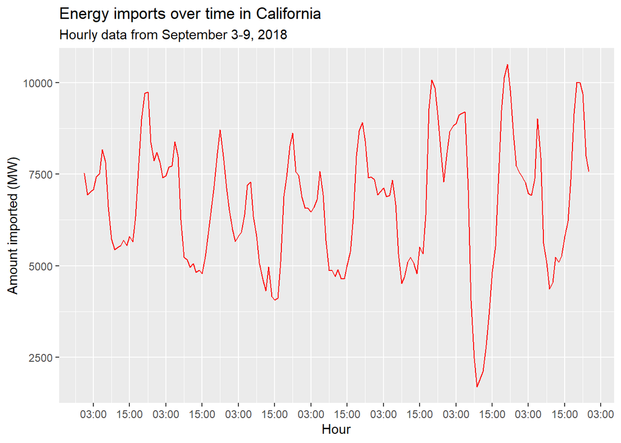

```r
imports %>%
  ggplot() +
  geom_line(aes(x=datetime, y=imports), col="red") +
  scale_x_datetime(date_labels="%H:%M", date_breaks="12 hours") +
  labs(title="Energy imports over time in California", subtitle="Hourly data from September 3-9, 2018",
       x="Hour", y="Amount imported (MW)")
```

The most common use of scale layers is to specify and adjust color palettes used when plotting grouped data. We will see some examples of this in the below section on that topic.

## Themes

### Preset themes

ggplot comes with several preset themes, including:

- `theme_grey()`: this is the default
- `theme_bw()`: strip colors, including grey gradients
- `theme_dark()` and `theme_light()`: these change the backgrounds of the coordinate system
- `theme_minimal()` and `theme_void()`: these are what they sound like. Try them out!

For a full list, see the reference guide file on complete themes (looking up the help file for any of the above functions will open this file).

There are also many ggplot extension packages that provide additional themes.

### Manually modify theme components

Instead of using a pre-set theme, you can modulate many components of the default theme using the `theme()` function. In this manually controlled theme layer, some of the things you can modify:

- Angle, position, and other characteristics of axis labels (e.g. using `axis.labels.x = element_text()` argument in the `theme()` function).
- Angle, position, and other characteristics of legends (this is useful when plotting grouped data).
- Characteristics of the background of the plot (e.g. using the `plot.background =` argument).

For a full list of the components that can be modified in the theme layer, see the help file for `ggplot2::theme()`.

## Coordinate system adjustment

A common coordinate system adjustment layer is `coord_flip()`, which rotates the plot such that the `x` and `y` axes are flipped. Let’s see an example with the bar chart that we generated with `geom_col()` earlier in the session.

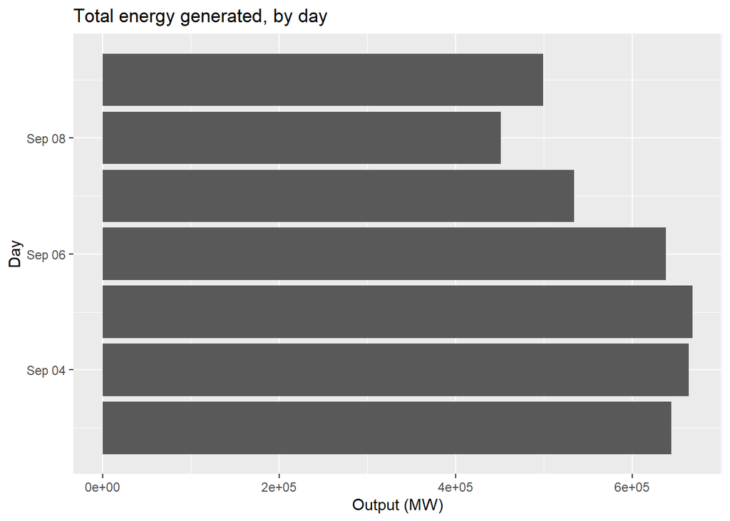

```r
long_gen %>%
  mutate(date=lubridate::date(datetime)) %>%
  group_by(date) %>%
  summarise(output=sum(output)) %>%
  ggplot() +
  geom_col(aes(x=date, y=output)) +
  labs(title="Total energy generated, by day", x="Day", y="Output (MW)") +
  coord_flip()
```

## Stats

There are several `stat` functions in ggplot that enable you to conduct statistical transformations of your data prior to plotting. `stat` and `geom` layers can be used interchangeably, as each `stat` layer has a `geom` argument and vice versa. Some reasons that you may want to use a `stat` layer instead of a `geom` layer, or specify the `stat` argument in a `geom` layer include:

- overriding the default setting, e.g. using `stat="identity"` to specify `y` values in `geom_bar()` instead of the default `stat="count"` which uses counts of each `x` value for the y-axis.
- using a transformed version of a variable for aesthetic mapping, e.g. proportions intead of counts in a bar chart.
- drawing attention to statistical transformations in your code.

Since these are relatively rare and more advanced use cases of ggplot, we will not explore them in detail here. If you are interested, see [Chapter 3.7 of the R for data science online textbook](http://r4ds.had.co.nz/data-visualisation.html#statistical-transformations).

# Visualizing grouped data

A common task in data visualization is plotting variables that are grouped, in order to make comparisons across groups or to show how a particular trend breaks down on a group level. For example, instead of visualizing energy generation as a whole, we may want to visualize generation from each source relative to ther sources.

There are two broad ways to visualize grouped data. One is to generate multiple geometric objects of the same type for each group by indicating the grouping variable using the `group =` function in the `aes()` function. Another is to use facets. We will examine both below. Throughout these examples, you will see one of the uses of converting data to long-format.

## Colors and fill

Note that the `col =` argument is specified within `aes()` here, as our goal is to map data values to the color aesthetics. When supplied outside the `aes()` function, the role of `col=` is to modify the color of the geometric object unrelated to any data values.

Although ggplot will generally interpret a `col =` argument inside `aes()` as providing a grouping variable, it is good practice to specify `group =` anyway.

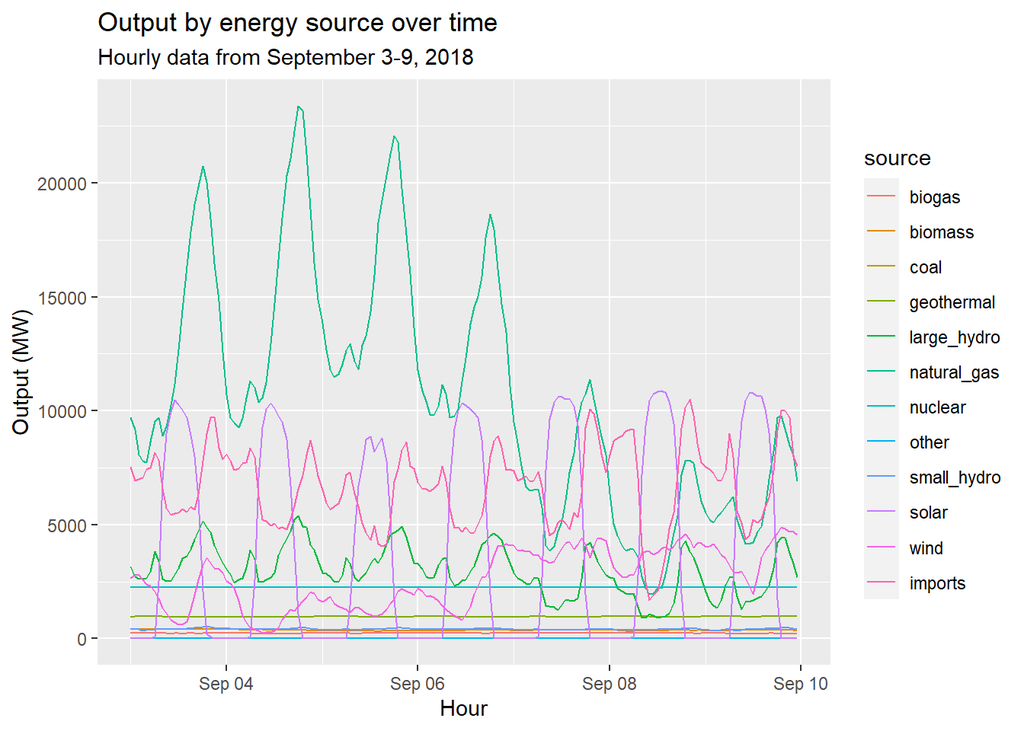

```r
long_merged_energy %>%
  ggplot() +
  geom_line(aes(x=datetime, y=output, group=source, col=source)) +
  labs(title="Output by energy source over time", subtitle="Hourly data from September 3-9, 2018",
       x="Hour", y="Output (MW)")
```

Let’s take a look at a more complex plot that uses grouping to generate multiple lines. For example, we might look at the above plot and think that the repeated patterns over multiple days is too noisy. Perhaps we are interested in the average trend over the course of a single day. To visualize this, we can plot the average output of each energy source per hour over the 7 days in the data. Comments are included in the code below describing what each step does. Note how the code for this plot combines several of the topics we have discussed so far (data manipulation before plotting, scales, themes, and labels).

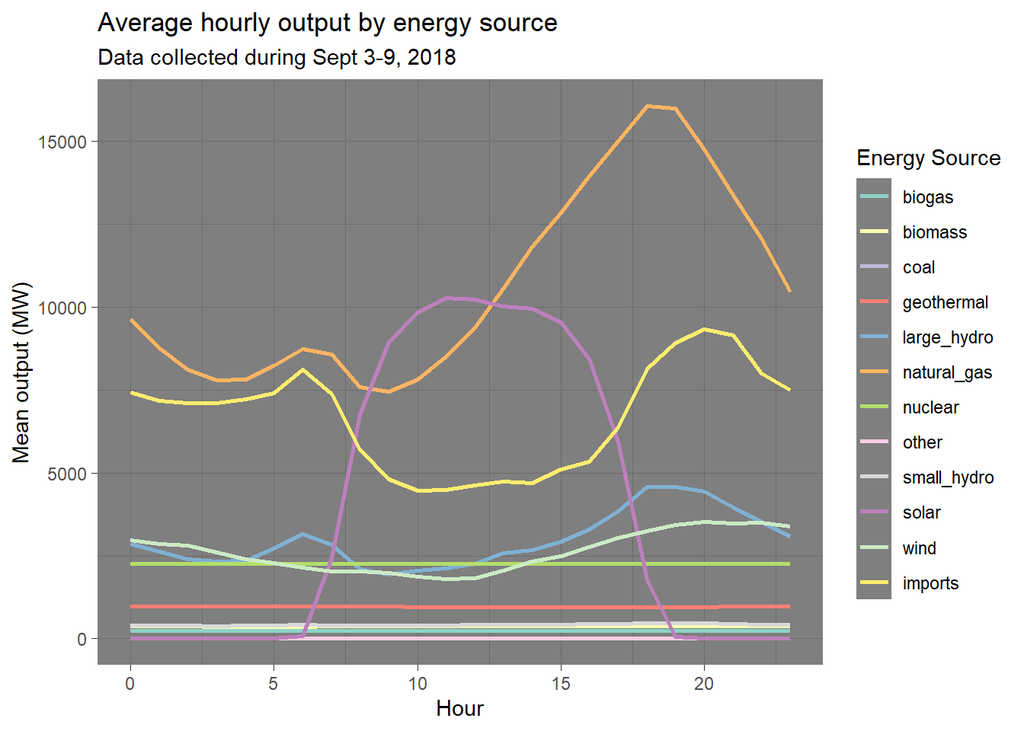

```r
long_merged_energy %>%
  # Create a variable indicating hour only
  mutate(hour=lubridate::hour(datetime)) %>%
  # Group data by hour and source
  group_by(hour, source) %>%
  # Compute mean output for each hour-source unit
  summarise(output=mean(output)) %>%
  # Pipe data into ggplot
  ggplot() +
  # Plot lines for output over hour, grouped by source
  geom_line(aes(x=hour, y=output, group=source, col=source), size=1) +
  # Use Set3 color palette to distinguish lines from each other, and give legend a title
  scale_color_brewer(palette="Set3", name="Energy Source") +
  # Use dark theme to make colors more visible +
  theme_dark() +
  # Add labels
  labs(title="Average hourly output by energy source", subtitle="Data collected during Sept 3-9, 2018",
       x="Hour", y="Mean output (MW)")
```

Remember from earlier that we may need to use either `col =` or `fill =` depending on the type of geometric object whose appearance we are trying to change. This is the same when we are mapping data to the colors. For example, in order to change the color of the objects in an area plot or bar chart, we will need to use `fill =` rather than `col =`.

## Position adjustment

In the above example, all groups are plotted overlaying each other. One way to visualize data more clearly, especially when we are dealing with bars or area plots rather than lines, is to use position adjustment.

For example, let’s plot a column chart with the total energy output per day. Note that we use the `fill =` argument here to demarcate each group in a different color. By default, ggplot stacks all the groups on top of each other.

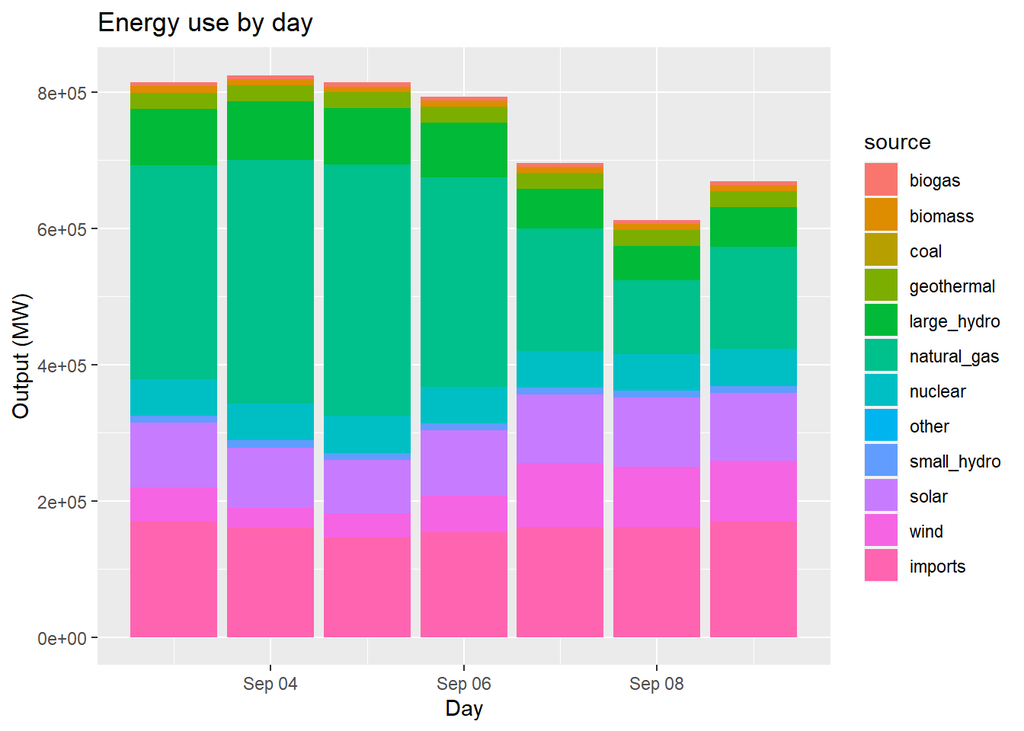

```r
long_merged_energy %>%
  mutate(date=lubridate::date(datetime)) %>%
  group_by(date, source) %>%
  summarize(output=sum(output)) %>%
  ggplot() +
  geom_col(aes(x=date, y=output, group=source, fill=source)) +
  labs(title="Energy use by day", x="Day", y="Output (MW)")
```

Instead of stacking the groups on top of each other, we can also use the `position = "dodge"` argument to create a column per group and arrange them next to each other horizontally.

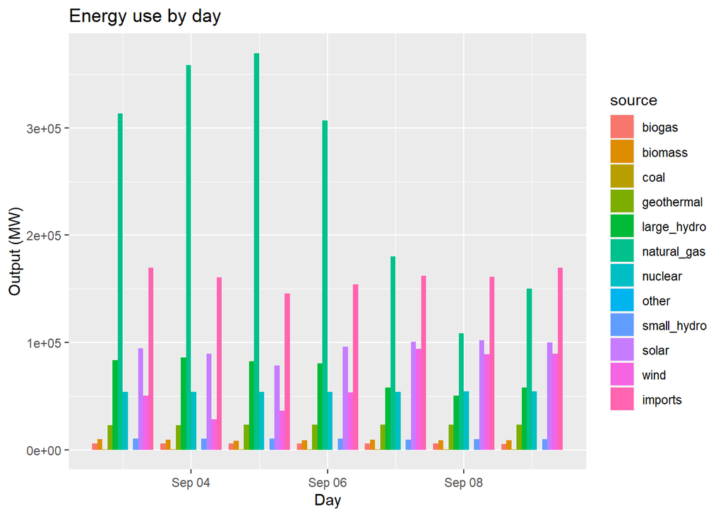

```r
long_merged_energy %>%
  mutate(date=lubridate::date(datetime)) %>%
  group_by(date, source) %>%
  summarize(output=sum(output)) %>%
  ggplot() +
  geom_col(aes(x=date, y=output, group=source, fill=source), position="dodge") +
  labs(title="Energy use by day", x="Day", y="Output (MW)")
```

A third alternative is to use `position = "fill"`, which normalizes the height of each bar and as such shows the proportion of the data in each bin that consists of each group.

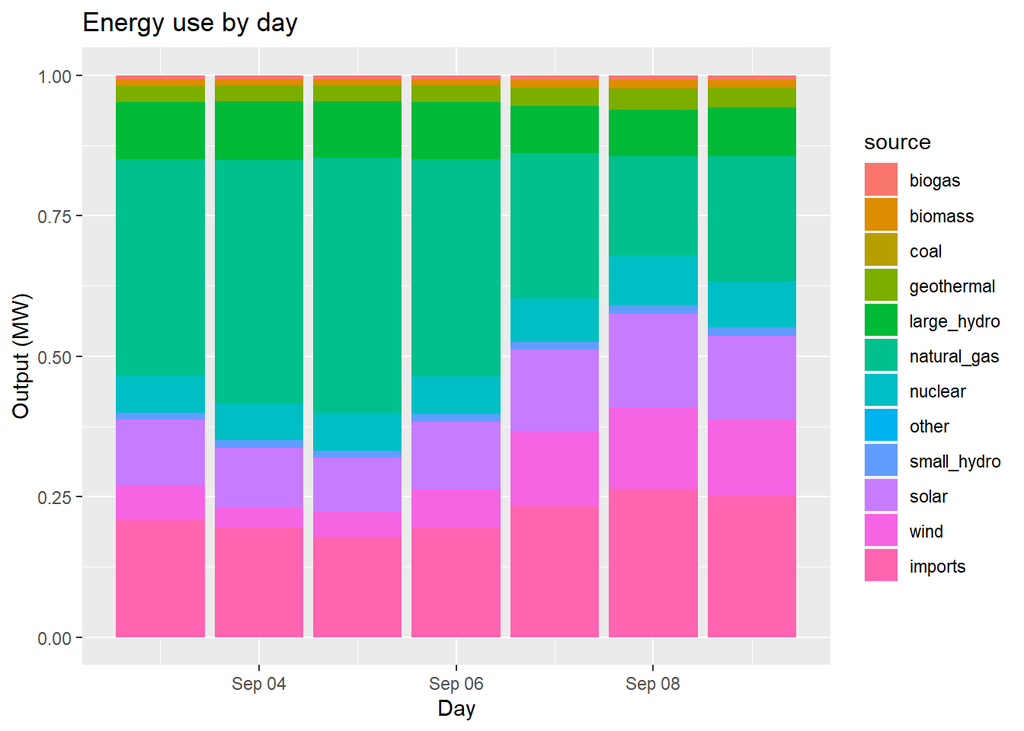

```r
long_merged_energy %>%
  mutate(date=lubridate::date(datetime)) %>%
  group_by(date, source) %>%
  summarize(output=sum(output)) %>%
  ggplot() +
  geom_col(aes(x=date, y=output, group=source, fill=source), position="fill") +
  labs(title="Energy use by day", x="Day", y="Output (MW)")
```

Let’s see another example of how position adjustment works with an area plot, of energy output over time by source. `geom_area()` defaults to `position="stack"` when using groups, but I have explicitly defined it here for illustration.

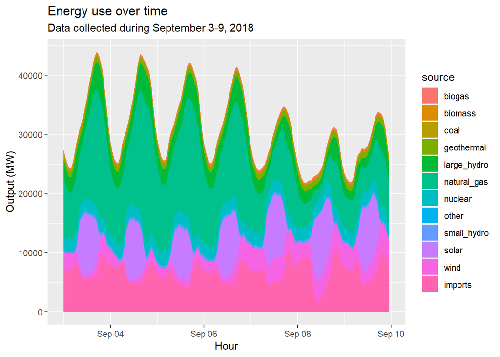

```r
long_merged_energy %>%
  ggplot() +
  geom_area(aes(x=datetime, y=output, group=source, fill=source), position="stack") +
  labs(title="Energy use over time", subtitle="Data collected during September 3-9, 2018",
       x="Hour", y="Output (MW)")
```

We might look at this plot and think it’s not particularly helpful. To simplify the above plot, we can do two things: (1) use the categories contained in the `regroup` data frame to reduce the number of categories; and (2) switch to `position="fill"` instead of `position="stack"`.

```r
# Make sure regroup data has been imported
regroup <- read_csv("data/ca_energy_regroup.csv")
```

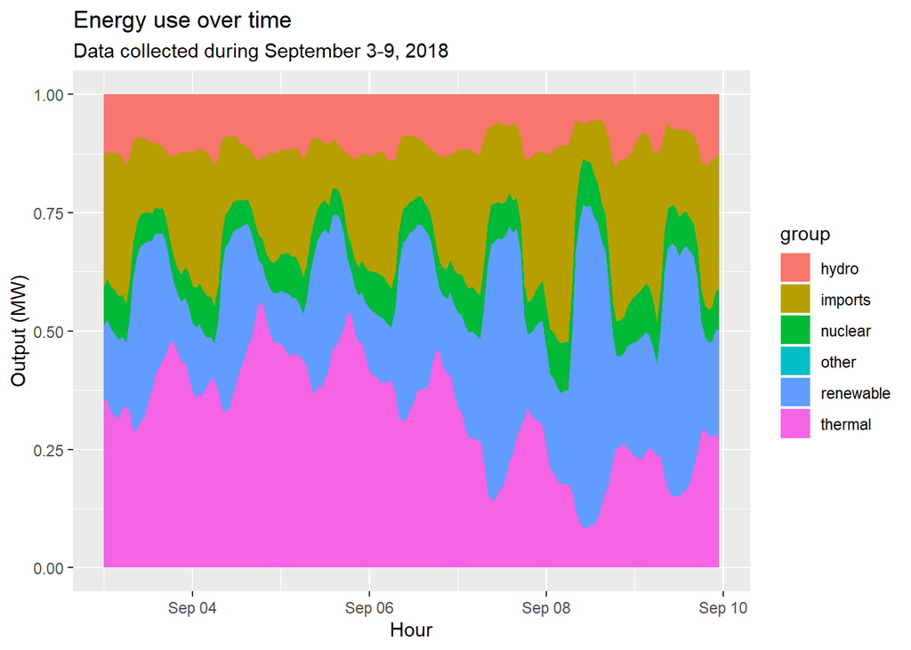

```r
# Prepare data frame
long_merged_energy %>%
  rename(type = source) %>%
  merge(regroup, by = "type") %>%
  group_by(datetime, group) %>%
  summarise(output=sum(output)) %>%
  # Pipe data into ggplot
  ggplot() +
  geom_area(aes(x=datetime, y=output, group=group, fill=group), position="fill") +
  labs(title="Energy use over time", subtitle="Data collected during September 3-9, 2018",
       x="Hour", y="Output (MW)")
```

## Shapes and linetypes

For certain `geom` functions, such as `geom_point()`, we can demarcate groups by shape. This is especially helpful in conjuction with line plots. For example, let’s plot total output by day, grouped using the grouping variable from `regroup`. First, we will plot lines and use colors to demarcate groups. Then, we will plot points and use shapes to demarcate groups.

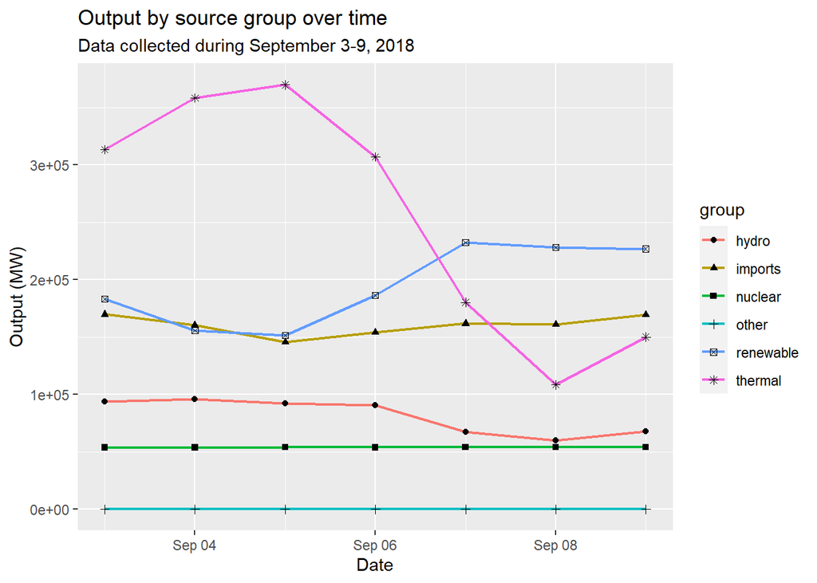

```r
# Prepare data
long_merged_energy %>%
  rename(type = source) %>%
  merge(regroup, by = "type") %>%
  mutate(date=lubridate::date(datetime)) %>%
  group_by(date, group) %>%
  summarise(output=sum(output)) %>%
  # Pipe data into ggplot
  ggplot() +
  geom_line(aes(x=date, y=output, group=group, col=group), size=0.8) +
  geom_point(aes(x=date, y=output, group=group, shape=group)) +
  labs(title="Output by source group over time", subtitle="Data collected during September 3-9, 2018",
       x="Date", y="Output (MW)")
```

The `shape =` approach works well for points, but when working with line plots, we can demarcate groups by `linetype =` instead. For example, instead of combining colored lines and shapes in the above plot, let’s use linetypes to demarcate groups.

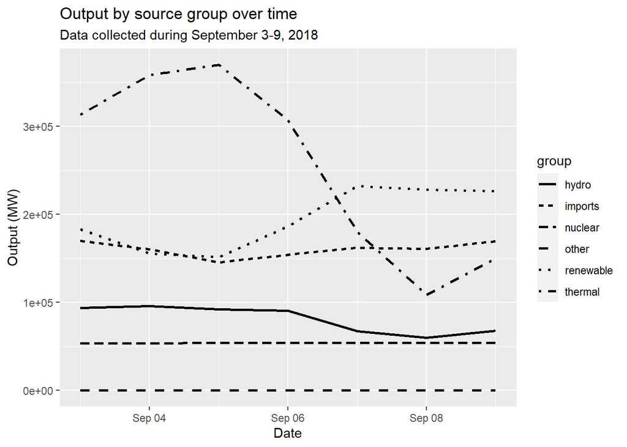

```r
# Prepare data
long_merged_energy %>%
  rename(type = source) %>%
  merge(regroup, by = "type") %>%
  mutate(date=lubridate::date(datetime)) %>%
  group_by(date, group) %>%
  summarise(output=sum(output)) %>%
  # Pipe data into ggplot
  ggplot() +
  geom_line(aes(x=date, y=output, group=group, linetype=group), size=1) +
  labs(title="Output by source group over time", subtitle="Data collected during September 3-9, 2018",
       x="Date", y="Output (MW)")
```

## Sizes and alpha

Especially useful for continuous variables, you can map the size and alpha (transparency) of geometric objects to data values. Since the grouping variables we have been working with in the California energy data are categorical, let us briefly return to the gapminder data to show an example. For example, you could create a scatterplot of the relationship between life expectancy and logged GDP per capita using the gapminder data, and map the values of population to the size of that points by using `aes(size=pop)` in `geom_point()`. To show how you can incorporate multiple grouping variables, I have also added `aes(col=continent)`.

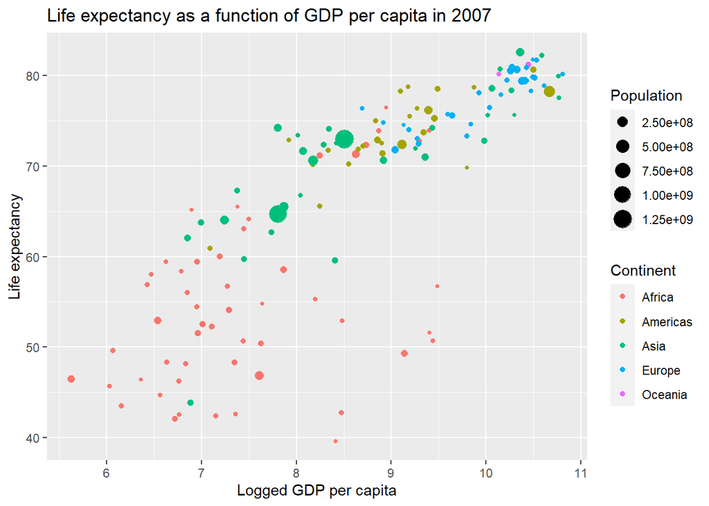

```r
gapminder07 %>%
  ggplot() +
  geom_point(aes(x=log(gdpPercap), y=lifeExp, size=pop, col=continent)) +
  scale_size_continuous(name="Population") +
  scale_color_discrete(name="Continent") +
  labs(title="Life expectancy as a function of GDP per capita in 2007",
       x="Logged GDP per capita", y="Life expectancy")
```

## Facets

While color, fill, shapes, and linetypes are useful ways to plot grouped data, we sometimes want to separate the visualization for each group even more clearly. To do so, we can use faceting, i.e. plot each group on a separate coordinate system. The simplest way to create facets using a grouping variable is `facet_wrap()`, but you can also control the arrangement of facets or use two grouping variables with `facet_grid()`.

Let’s say we are interested in examining trends in energy generation by source. Using the skills we’ve learned so far, we could generate a line plot as follows.

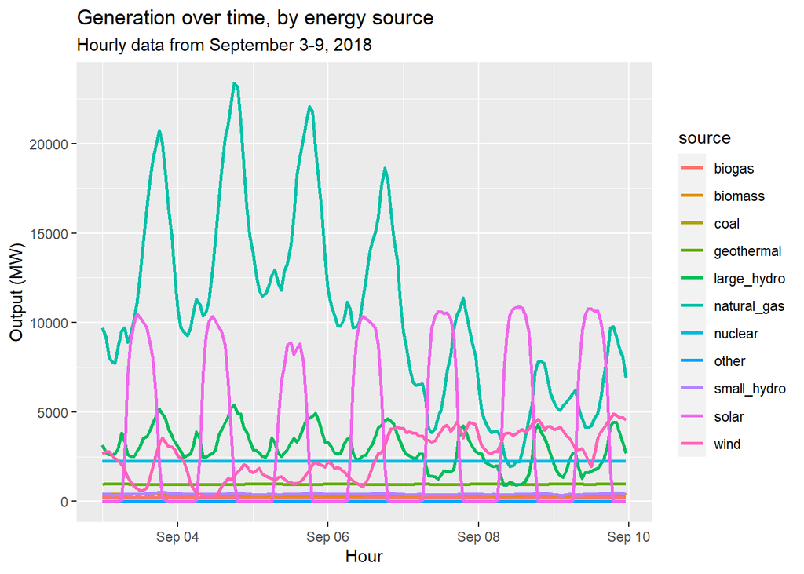

```r
long_gen %>%
  ggplot() +
  geom_line(aes(x=datetime, y=output, group=source, col=source), size=1) +
  labs(title="Generation over time, by energy source", subtitle="Hourly data from September 3-9, 2018",
       x="Hour", y="Output (MW)")
```

But this feels too noisy, especially if our primary goal is to visualize the trend for each source. An alternative strategy is to *facet* by source rather than using a color aesthetic to separate each source.

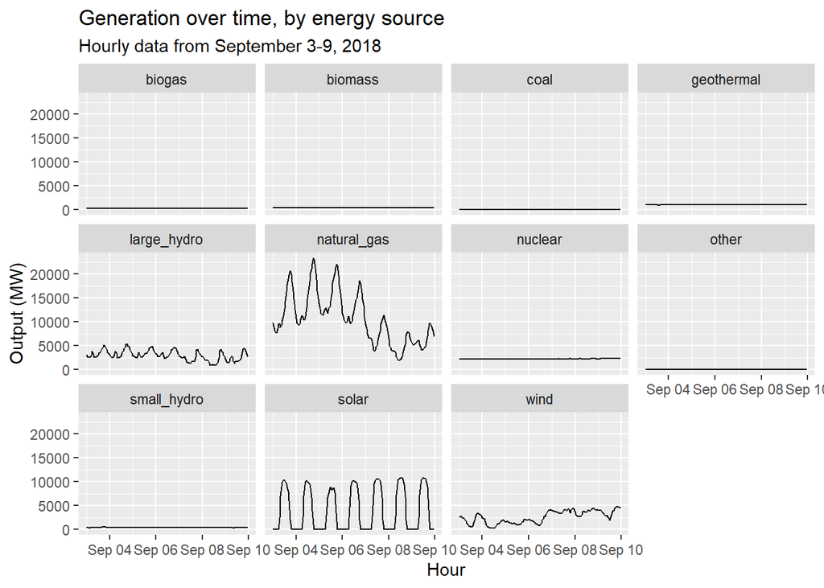

```r
long_gen %>%
  ggplot() +
  geom_line(aes(x = datetime, y = output)) +
  facet_wrap(~source) +
  labs(title="Generation over time, by energy source", subtitle="Hourly data from September 3-9, 2018",
       x="Hour", y="Output (MW)")
```

This is a little better! But note that the scales for each coordinate system are fixed, i.e. the scale limits are the same for each plot. If our main goal is to examine the patterns over time for each source, rather than comparing the sources to each other, we can specify `scales="free"` in `facet_wrap()`.

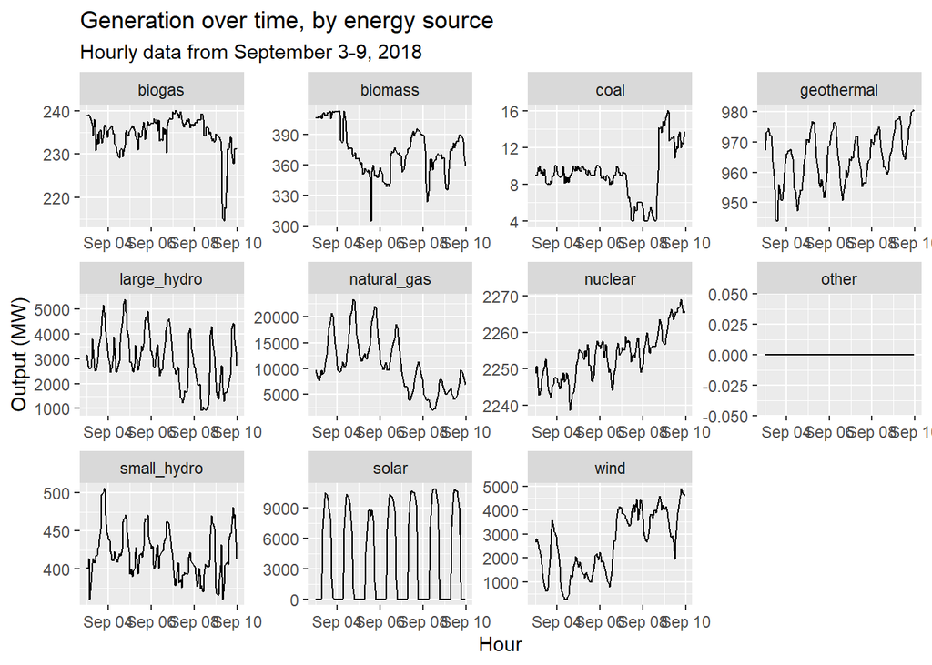

```r
long_gen %>%
  ggplot() +
  geom_line(aes(x = datetime, y = output)) +
  facet_wrap(~source, scales="free") +
  labs(title="Generation over time, by energy source", subtitle="Hourly data from September 3-9, 2018",
       x="Hour", y="Output (MW)")
```

That’s much better! Note that we can combine faceting with the previous skills we’ve learned to incorporate multiple groupings. For example, we can use map the source groups in `regroup` to the color aesthetic in `geom_line` as follows. Since this is a fairly complicated mix of data manipulation and visualization, comments are included describing each step.

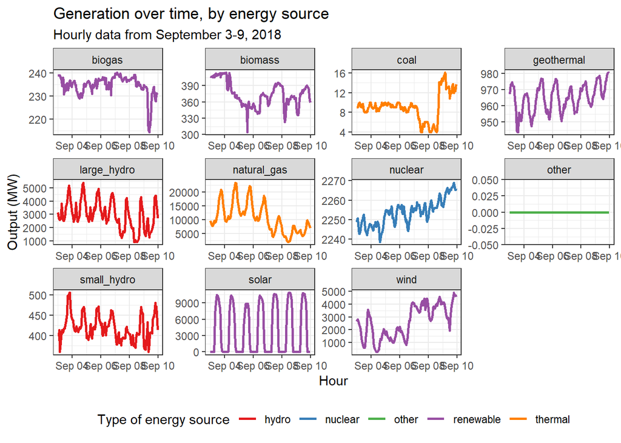

```r
# Begin data preparation
long_gen %>%
  # Rename "source" variable to "type", to prepare for merging
  rename(type = source) %>%
  # Merge energy generation data with regroup data by "source" variable
  merge(regroup, by = "type") %>%
  # Pipe data into dplyr
  ggplot() +
  # Generate lines of output ~ datetime, color based on "group" variable, and increase size
  geom_line(aes(x=datetime, y=output, group=group, col=group), size=1) +
  # Adjust color palette for "group" colors and give legend a better name
  scale_color_brewer(palette="Set1", name="Type of energy source") +
  # Create facets by source, with free scales
  facet_wrap(~type, scales="free") +
  # Add labels
  labs(title="Generation over time, by energy source", subtitle="Hourly data from September 3-9, 2018",
       x="Hour", y="Output (MW)") +
  # Use the minmal theme
  theme_bw() +
  # Customize theme to move the legend to the bottom
  theme(legend.position = "bottom")
```

# Final notes

## Comment your code

In some of the examples above, you have seen that we can write comments within a flow of `%>%` or `+` operators. It is highly recommended that you use such comments when doing complex data manipulation or data visualization tasks, or indeed when doing both together. This enables not only others to read your code, but also aids your own understanding of the code when returning to it at a later time.

## Saving images

Graphics generated using `ggplot2` can be saved as images in three ways:

1. Write the result of the code to a named object, which will live in your environment. You can save objects in your environment to an image as usual.
2. Once the plot has been generated in the “Plots” tab in the bottom-right pane, you can use the “save” icon in that tab to save the image file. You will be able to change the directory and modify the dimensions of the image when you do this.
3. Use the `ggsave()` function as an additional layer at the end of your code. You must specify the filename when using `ggsave()`, and can additionally specify the filepath (if different from working directory) and dimensions of the image, along with many other settings.

Let’s see an example where we combine methods 1 and 3. First, we will save a graphic as an object, and then call the object and add a `ggsave()` layer to create a `.png` file in our directory.

```r
# Save a column chart of imports over time
plot_importsovertime <- ggplot(imports) +
  geom_line(aes(x=datetime, y=imports), col="red") +
  scale_x_datetime(date_labels="%H:%M", date_breaks="12 hours") +
  labs(title="Energy imports over time in California", subtitle="Hourly data from September 3-9, 2018",
       x="Hour", y="Amount imported (MW)")

# Save the plot as an image
plot_importsovertime + ggsave("importsovertime.png", width=5, height=3)
```